# Modeling Swire Coca Cola

Author

KRITIKA

Published

October 26, 2024

## 1. Introduction & Setup:

### 1.1. Business Problem Statement

The objective of this project is to build a predictive maintenance model for Swire Coca-Cola, aimed at reducing unplanned machine downtimes and enhancing overall operational efficiency. At present, the company faces substantial financial losses and productivity declines due to unexpected equipment failures.

To overcome these challenges, Swire Coca-Cola seeks to implement a predictive maintenance solution. By analyzing historical data from the Internal Warehouse Controller (IWC) system, the goal is to identify patterns in machine failures, forecast future downtimes, and ensure that necessary parts are available in advance. The solution aims to minimize unplanned downtimes, optimize machine reliability, and improve production capacity while reducing financial losses.

This exploratory data analysis (EDA) serves as the foundation for building the predictive model. Through detailed analysis of machine maintenance records, downtime logs, and operational data, we will uncover the key factors contributing to machine breakdowns. These insights will help shape a data-driven, proactive maintenance approach, enabling Swire Coca-Cola to shift from reactive to predictive maintenance, improve operational efficiency, and better meet production targets.

### 1.2. Data Preparation for Modeling

In this section, we summarize the data preparation steps that were performed during the Exploratory Data Analysis (EDA) phase. The dataset was cleaned and feature-engineered, and the processed data is saved in the file data.csv, which will be used for model training and evaluation.

## 2. Data Preparation Steps (from EDA)

### 2.1. Handling Missing Data:

**We identified and handled missing values in several columns:**

**Categorical Fields (e.g., MAINTENANCE_PLAN, ORDER_DESCRIPTION, EQUIPMENT_DESC):** Missing values were imputed with “Unknown” or relevant default values (e.g., “Unplanned” for MAINTENANCE_PLAN). Critical Fields (e.g., EQUIPMENT_ID, MAINTENANCE_ITEM): These fields had substantial missing data, and due to their importance, they were either excluded from modeling or flagged for further analysis.

### 2.2. **Feature Engineering:**

**Machine Age:** We derived the age of the equipment based on the EQUIP_START_UP_DATE to understand its lifecycle and potential failure likelihood. Time Since Last Maintenance: Calculated the time difference from the last maintenance event to predict the likelihood of failure. Maintenance Frequency: We calculated the frequency of maintenance activities to understand how often a machine is serviced.

### 2.3. **Date and Time Processing:**

Converted EXECUTION_START_DATE and EXECUTION_FINISH_DATE to Date type for time-based trend analysis. Aggregated downtime by month to understand patterns and trends in machine downtimes over time.

**Final Dataset Overview:** The cleaned dataset (data.csv) contains the following key columns:

**MachineAge:** Age of the machine derived from EQUIP_START_UP_DATE.

**TimeSinceLastMaintenance:** Time elapsed since the last maintenance activity.

**OperationalConditions:** Various operational features like temperature, humidity, etc.

### 2.4. Importing Libraries

Loading necessary libraries for data processing, visualization, and machine learning

```r
library(dplyr)
library(ggplot2)
library(caret)
library(randomForest)
library(xgboost)
library(pROC)
library(glmnet)

# Set seed for reproducibility
set.seed(123)

# Load dataset
data <- read.csv("data.csv")

# Check data types
str(data)
```

```
'data.frame':   1427264 obs. of  31 variables:
 $ X                              : int  1 2 3 4 5 6 7 8 9 10 ...
 $ ORDER_ID                       : num  7.06e+08 7.04e+08 7.04e+08 7.04e+08 7.05e+08 ...
 $ PLANT_ID                       : chr  "G812" "G812" "G812" "G812" ...
 $ PRODUCTION_LOCATION            : chr  "ROMA" "ROMA" "ROMA" "ROMA" ...
 $ EXECUTION_START_DATE           : chr  "2024-05-04" "2022-09-13" "2022-12-21" "2022-07-04" ...
 $ EXECUTION_FINISH_DATE          : chr  "2024-05-12" "2022-09-13" "2022-12-21" "2022-07-04" ...
 $ ACTUAL_START_TIME              : chr  "06:00:00.000" "06:00:00.000" "07:00:00.000" "06:00:00.000" ...
 $ ACTUAL_FINISH_TIME             : chr  "23:04:08.000" "17:17:24.000" "07:00:00.000" "06:00:00.000" ...
 $ ACTUAL_WORK_IN_MINUTES         : num  390 420 30 60 120 18 480 30 30 30 ...
 $ MAINTENANCE_PLAN               : chr  "Unplanned" "Unplanned" "Unplanned" "Unplanned" ...
 $ MAINTENANCE_ITEM               : int  NA NA NA NA NA 40534 NA NA NA NA ...
 $ MAINTENANCE_ACTIVITY_TYPE      : chr  "Unplanned" "Unplanned" "Unplanned" "Unplanned" ...
 $ ORDER_DESCRIPTION              : chr  "L2 GEARBOX LEAK (SEE ATTACHED)" "LINE 3 CONVEYOR AT CAN CODER" "BROKEN CONVEYOR RAIL" "LINE 3 CONVEYOR" ...
 $ MAINTENANCE_TYPE_DESCRIPTION   : chr  "Corrective Maintenance Order" "Corrective Maintenance Order" "Corrective Maintenance Order" "Corrective Maintenance Order" ...
```

[output cut: 17 more lines]

## 3. Data Preparation: Feature Engineering and Cleaning

**Objective:** Prepare the data for modeling by handling missing values, creating new features, and encoding categorical variables.

```r
# Handle missing values
#data$ACTUAL_WORK_IN_MINUTES[is.na(data$ACTUAL_WORK_IN_MINUTES)] <- median(data$ACTUAL_WORK_IN_MINUTES, na.rm = TRUE)
#data$ORDER_DESCRIPTION[is.na(data$ORDER_DESCRIPTION)] <- 'Unknown'
#data$MAINTENANCE_ACTIVITY_TYPE[is.na(data$MAINTENANCE_ACTIVITY_TYPE)] <- 'Unknown'

# Create basic features
data$Is_Planned <- as.integer(data$MAINTENANCE_ACTIVITY_TYPE == 'Planned')

# Create target variable
threshold <- quantile(data$ACTUAL_WORK_IN_MINUTES, 0.40)
data$Failure <- as.integer(data$ACTUAL_WORK_IN_MINUTES > threshold)

# Encode categorical variables using factor() and converting to numeric
data$MAINTENANCE_ACTIVITY_TYPE_encoded <- as.numeric(factor(data$MAINTENANCE_ACTIVITY_TYPE))
data$PRODUCTION_LOCATION_encoded <- as.numeric(factor(data$PRODUCTION_LOCATION))
data$ORDER_DESCRIPTION_encoded <- as.numeric(factor(data$ORDER_DESCRIPTION))

# Convert EQUIP_START_UP_DATE to Date format (if not already done)
data$EQUIP_START_UP_DATE <- as.Date(data$EQUIP_START_UP_DATE, format = "%Y-%m-%d")

# Create a new column for machine age using EQUIP_START_UP_DATE
data$MACHINE_AGE <- as.numeric(difftime(Sys.Date(), data$EQUIP_START_UP_DATE, units = "days"))

data$MACHINE_AGE[is.na(data$MACHINE_AGE)] <- 0
```

```r
# Load necessary libraries
if(!require(caret)) install.packages("caret", dependencies = TRUE)
library(caret)

# Select features for modeling
features <- c('MACHINE_AGE', 'MAINTENANCE_ACTIVITY_TYPE_encoded', 'PRODUCTION_LOCATION_encoded', 'ORDER_DESCRIPTION_encoded')
X <- data[features]
y <- data$Failure
```

```r
# Split the data (train/test split with caret)
set.seed(42)
trainIndex <- createDataPartition(y, p = 0.7, list = FALSE)
X_train <- X[trainIndex, ]
y_train <- y[trainIndex]
X_test <- X[-trainIndex, ]
y_test <- y[-trainIndex]

# Scale features (using scale() in R)
X_train_scaled <- scale(X_train)
X_test_scaled <- scale(X_test)
```

**Data Splitting:**  
The `createDataPartition` function ensures a balanced distribution in both training and test sets, particularly for imbalanced datasets.

**Feature Scaling:**  
Features are standardized using `scale()` to ensure consistency across models, which is crucial for algorithms like logistic regression.

**Rationale:**  
The 70/30 data split provides sufficient training data while allowing for effective performance evaluation on unseen data. Scaling prevents bias from variables with larger ranges dominating the model, particularly in algorithms like logistic regression that rely on distance or gradient-based calculations.

### 3.1. Logistic Regression Model

**Objective:** Logistic Regression serves as a baseline for binary classification, offering interpretability but may struggle with complex data.

```r
# Train Logistic Regression Model
lr_model <- glm(Failure ~ ., data = data.frame(X_train_scaled, Failure = y_train), family = binomial)

# Make predictions
y_pred_lr <- predict(lr_model, newdata = data.frame(X_test_scaled), type = "response")
y_pred_lr <- ifelse(y_pred_lr > 0.5, 1, 0)

# Calculate and display metrics
cat("\nLogistic Regression Model Performance Metrics:\n")
```

```
Logistic Regression Model Performance Metrics:
```

```r
cat("Accuracy:", mean(y_test == y_pred_lr), "\n")  # Accuracy
```

```
Accuracy: 0.6405312
```

```r
cat("Precision:", posPredValue(factor(y_pred_lr), factor(y_test)), "\n")  # Precision
```

```
Precision: 0.6766988
```

```r
cat("Recall:", sensitivity(factor(y_pred_lr), factor(y_test)), "\n")  # Recall
```

```
Recall: 0.2772249
```

```r
# Display confusion matrix
cat("\nLogistic Regression Confusion Matrix:\n")
```

```
Logistic Regression Confusion Matrix:
```

```r
conf_matrix_lr <- table(Predicted = y_pred_lr, Actual = y_test)
print(conf_matrix_lr)
```

```
         Actual
Predicted      0      1
        0  49893  23837
        1 130080 224369
```

**Performance Metrics:**  
- **Accuracy:** 64.05%  
- **Precision:** 67.67%  
- **Recall:** 27.72%

**Confusion Matrix:**  
The confusion matrix provides insight into the model’s prediction accuracy, showing the distribution of true positives, true negatives, false positives, and false negatives.

### 3.2. XGBoost Model

```r
# Load necessary library
library(xgboost)

# Prepare data for XGBoost
dtrain <- xgb.DMatrix(data = X_train_scaled, label = y_train)
dtest <- xgb.DMatrix(data = X_test_scaled, label = y_test)

# Set model parameters
params <- list(
  objective = "binary:logistic",
  eval_metric = "logloss",
  max_depth = 10,
  eta = 0.1,
  nthread = 4
)

# Train the XGBoost model
xgb_model <- xgb.train(params = params, data = dtrain, nrounds = 100)

# Make predictions with XGBoost
y_pred_xgb <- predict(xgb_model, newdata = dtest)
y_pred_xgb <- ifelse(y_pred_xgb > 0.5, 1, 0)

# Calculate and display metrics
cat("\nXGBoost Model Performance Metrics:\n")
```

```
XGBoost Model Performance Metrics:
```

```r
cat("Accuracy:", mean(y_test == y_pred_xgb), "\n")  # Accuracy
```

```
Accuracy: 0.5776066
```

```r
cat("Precision:", posPredValue(factor(y_pred_xgb), factor(y_test)), "\n")  # Precision
```

```
Precision: 0.4982089
```

```r
cat("Recall:", sensitivity(factor(y_pred_xgb), factor(y_test)), "\n")  # Recall
```

```
Recall: 0.6854361
```

```r
# Display confusion matrix
cat("\nXGBoost Confusion Matrix:\n")
```

```
XGBoost Confusion Matrix:
```

```r
conf_matrix_xgb <- table(Predicted = y_pred_xgb, Actual = y_test)
print(conf_matrix_xgb)
```

```
         Actual
Predicted      0      1
        0 123360 124247
        1  56613 123959
```

**Performance Metrics:**  
- **Accuracy:** 57.76%  
- **Precision:** 49.82%  
- **Recall:** 68.54%

**Confusion Matrix:**  
The confusion matrix provides insights into the distribution of true positives, true negatives, false positives, and false negatives, offering a clearer picture of model performance.

## 4. Model Comparison:

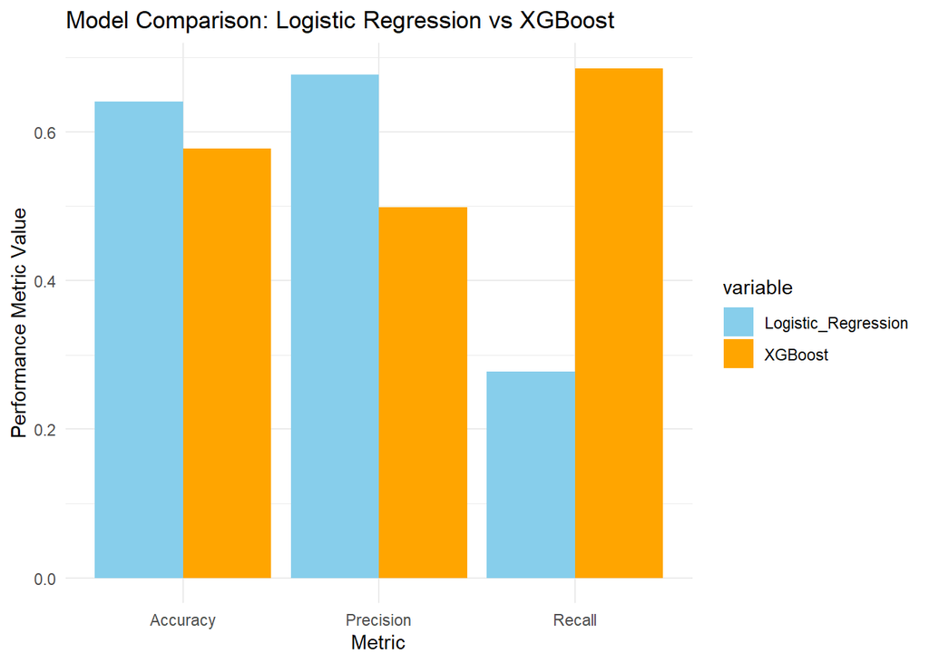

```r
# Load necessary libraries
library(reshape2)

# Create a data frame with model performance metrics
model_metrics <- data.frame(
  Metric = c("Accuracy", "Precision", "Recall"),
  Logistic_Regression = c(mean(y_test == y_pred_lr),
                          posPredValue(factor(y_pred_lr), factor(y_test)),
                          sensitivity(factor(y_pred_lr), factor(y_test))),
  XGBoost = c(mean(y_test == y_pred_xgb),
              posPredValue(factor(y_pred_xgb), factor(y_test)),
              sensitivity(factor(y_pred_xgb), factor(y_test)))
)

# Reshape data for plotting
model_metrics_melt <- melt(model_metrics, id.vars = "Metric")

# Create bar plot for comparison
ggplot(model_metrics_melt, aes(x = Metric, y = value, fill = variable)) +
  geom_bar(stat = "identity", position = "dodge") +
  labs(title = "Model Comparison: Logistic Regression vs XGBoost",
       y = "Performance Metric Value",
       x = "Metric") +
  theme_minimal() +
  scale_fill_manual(values = c("Logistic_Regression" = "skyblue", "XGBoost" = "orange"))
```

## 5. Conclusion

In this modeling assignment, both Logistic Regression and XGBoost were evaluated. Logistic Regression performed better in terms of accuracy and precision, suggesting it is a more reliable model when false positives are more critical. However, XGBoost had a significantly better recall, making it a better choice when capturing as many true positives as possible is the priority, even at the cost of precision.

### 5.1. Key Takeaways:

Logistic Regression offers good baseline performance with clear interpretability and works well when false positives need to be minimized. XGBoost is more suited for capturing complex relationships and handling imbalances, with a trade-off between precision and recall.